# Esempio1_Es4

# 1 TESTO

L’efficienza di un programma dipende dalla dimensione dei dati che riceve come input. In generale, dataset di dimensioni più grandi richiedono tempi di elaborazione più elevati, riducendo il numero di processi elaborati in una data unità di tempo. Il dataset efficienza.csv contiene il numero di richieste elaborate per ora per un campione casuale di 29 dataset di varie dimensioni misurate in Gigabyte.

Si risponda ai seguenti quesiti:

si costruisca un modello per prevedere quanti processi vengono elaborati in un’ora in funzione della dimensione dei dati ricevuti dal programma;

si illustri il modello calcolando un intervallo di previsione al 95% per il numero di processi elaborati in un’ora nel caso di (i) un dataset di dimensione 10 Gigabyte e (ii) nel caso di un dataset di dimensione 15 Gigabyte.

# 2 SOLUZIONE

## 2.1 Punto 1

Leggiamo e visualizziamo i dati:

```r
efficienza <- read.csv("efficienza.csv")
head(efficienza)
```

|  | processi | dimensione |
| --- | --- | --- |
| 1 | 11 | 17 |
| 2 | 56 | 10 |
| 3 | 27 | 13 |
| 4 | 25 | 17 |
| 5 | 34 | 14 |
| 6 | 88 | 17 |

Visualizzo i dati tramite grafico:

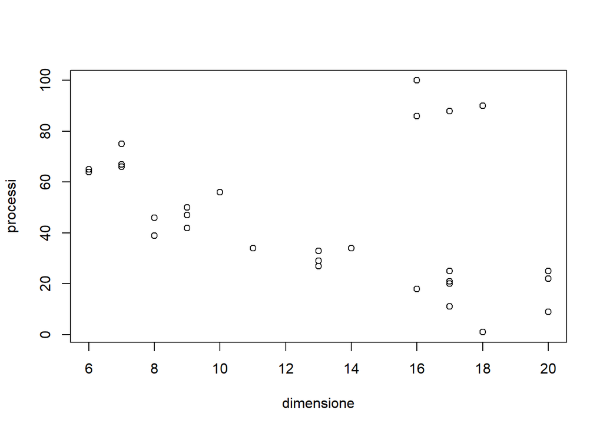

```r
plot(processi ~ dimensione, data = efficienza)
```

Noto dal grafico che non è di facile interpretazione e che inoltre ci sono dati che potrebbero sfasare la stima del modello.

Stimiamo la retta di regressione:

```r
mod <- lm(processi ~ dimensione, data = efficienza)
summary(mod)
```

```
##
## Call:
## lm(formula = processi ~ dimensione, data = efficienza)
##
## Residuals:
##     Min      1Q  Median      3Q     Max
## -33.143 -15.627  -8.530   5.695  61.663
##
## Coefficients:
##             Estimate Std. Error t value Pr(>|t|)
## (Intercept)   71.887     14.047   5.118 2.22e-05 ***
## dimensione    -2.097      1.013  -2.070   0.0482 *
## ---
## Signif. codes:  0 '***' 0.001 '**' 0.01 '*' 0.05 '.' 0.1 ' ' 1
##
## Residual standard error: 25.26 on 27 degrees of freedom
## Multiple R-squared:  0.1369, Adjusted R-squared:  0.105
## F-statistic: 4.284 on 1 and 27 DF,  p-value: 0.04817
```

Analisi dei residui:

```r
library(car)
```

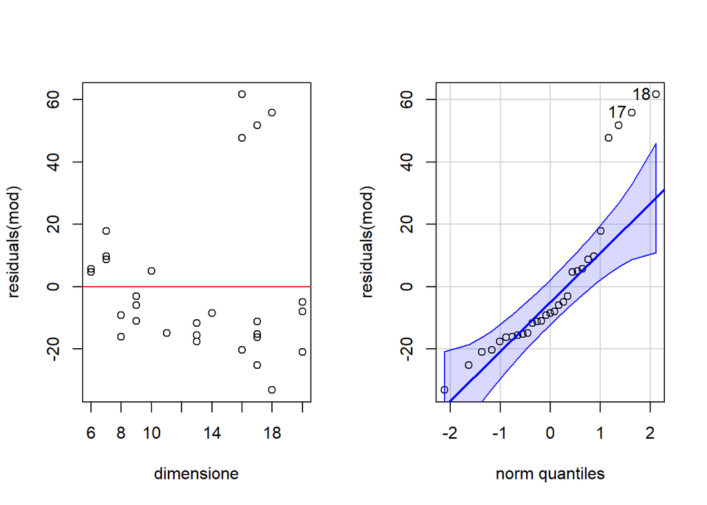

```
## [1] 18 17
```

```r
par(mfrow = c(1, 2))
plot(residuals(mod) ~ dimensione, data = efficienza)
abline(h = 0, col = "red")
qqPlot(residuals(mod))
```

Trovo le osservazioni anomale:

```r
outliers <- which(efficienza$processi > 80)
outliers
```

```
## [1]  6 12 17 18
```

Sembra essere un modello quadratico, lo stimo con le osservazioni anomale:

```r
mod <- lm(processi ~ dimensione + I(dimensione^2), data = efficienza)
summary(mod)
```

```
##
## Call:
## lm(formula = processi ~ dimensione + I(dimensione^2), data = efficienza)
##
## Residuals:
##     Min      1Q  Median      3Q     Max
## -33.340 -15.065  -9.130   5.615  62.129
##
## Coefficients:
##                 Estimate Std. Error t value Pr(>|t|)
## (Intercept)     77.65236   45.39156   1.711    0.099 .
## dimensione      -3.12734    7.76788  -0.403    0.691
## I(dimensione^2)  0.04006    0.29932   0.134    0.895
## ---
## Signif. codes:  0 '***' 0.001 '**' 0.01 '*' 0.05 '.' 0.1 ' ' 1
##
## Residual standard error: 25.74 on 26 degrees of freedom
## Multiple R-squared:  0.1375, Adjusted R-squared:  0.07119
## F-statistic: 2.073 on 2 and 26 DF,  p-value: 0.1461
```

Ora lo stimo senza le osservazioni anomale:

```r
mod2 <- lm(processi ~ dimensione + I(dimensione^2), data = efficienza, subset = -outliers)
summary(mod2)
```

```
##
## Call:
## lm(formula = processi ~ dimensione + I(dimensione^2), data = efficienza,
##     subset = -outliers)
##
## Residuals:
##      Min       1Q   Median       3Q      Max
## -16.1198  -4.0948  -0.2255   6.0238  14.0238
##
## Coefficients:
##                  Estimate Std. Error t value Pr(>|t|)
## (Intercept)     121.76706   14.73409   8.264 3.43e-08 ***
## dimensione      -10.51119    2.52539  -4.162 0.000406 ***
## I(dimensione^2)   0.26097    0.09676   2.697 0.013164 *
## ---
## Signif. codes:  0 '***' 0.001 '**' 0.01 '*' 0.05 '.' 0.1 ' ' 1
##
## Residual standard error: 8.124 on 22 degrees of freedom
## Multiple R-squared:  0.852,  Adjusted R-squared:  0.8386
## F-statistic: 63.33 on 2 and 22 DF,  p-value: 7.452e-10
```

Analisi dei residui:

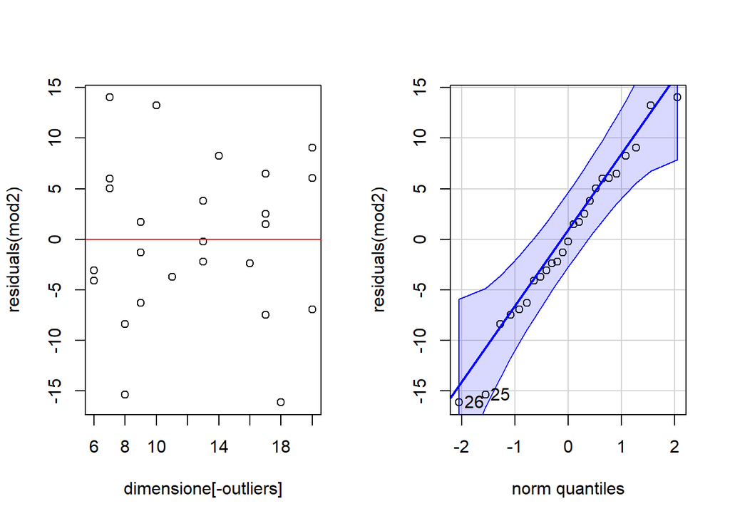

```
## 26 25
## 22 21
```

```r
par(mfrow = c(1, 2))
plot(residuals(mod2) ~ dimensione[-outliers], data = efficienza)
abline(h = 0, col = "red")
qqPlot(residuals(mod2))
```

Dalle analisi dei risidui noto che il modello di regressione è appropriato.

Visualizzo i due modelli stimati:

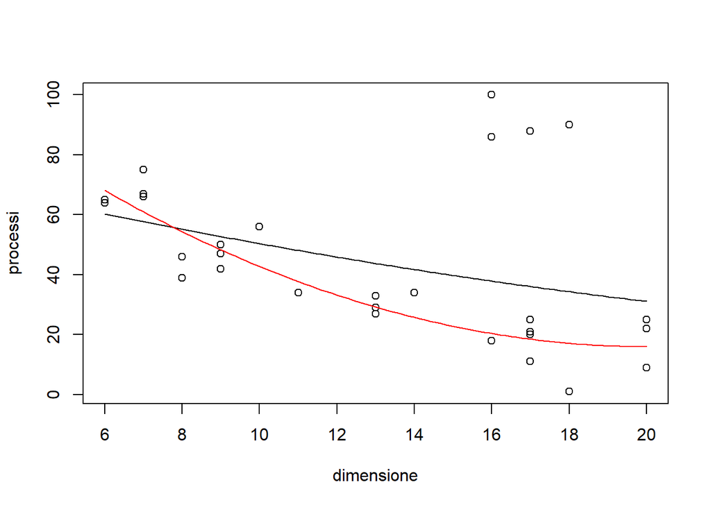

```r
plot(processi ~ dimensione, data = efficienza)
curve(coef(mod)[1] + coef(mod)[2] * x + coef(mod)[3] * x^2, from = min(efficienza$dimensione), to = max(efficienza$dimensione), add = TRUE)

curve(coef(mod2)[1] + coef(mod2)[2] * x + coef(mod2)[3] * x^2, from = min(efficienza$dimensione), to = max(efficienza$dimensione), add = TRUE, col = "red")
```

Il modello spiega 85% della variabilità del numero di processi elaborati in un’ora.

## 2.2 Punto 2

Calcolo l’intervallo di previsione al 95% per il numero di processi elaborati in un’ora nel caso di un dataset di dimensione 10 Gigabyte:

```r
pr <- predict(mod2, newdata = data.frame(dimensione = 10), interval = "prediction", level = 0.95)
pr
```

```
##        fit      lwr      upr
## 1 42.75213 25.25709 60.24717
```

Calcolo l’intervallo di previsione al 95% per il numero di processi elaborati in un’ora nel caso di un dataset di dimensione 15 Gigabyte:

```r
pr <- predict(mod2, newdata = data.frame(dimensione = 15), interval = "prediction", level = 0.95)
pr
```

```
##        fit      lwr      upr
## 1 22.81737 5.162408 40.47234
```